# Hierarchical Clustering

Ryan McGuinness

11/23/2021

## Problem Description

We will use hierarchical clustering on a dataset consisting of nutritional information, in-store display information, and consumer ratings for 77 cereals. Specifically, we will

- apply clustering to the data and, using Agnes, compare the clustering from single linkage, complete linkage, average linkage, and Ward to choose the best method,
- choose the number of clusters to use,
- comment on the structure and the stability of the clusters, and
- find a cluster of “healthy cereals” for a hypothetical elementary school seeking to feed their kids a healthy diet.

## Preprocessing Data

First, we read the dataset in R.

```r
Cereals.df <- read.csv("Cereals.csv")
head(Cereals.df)
```

```
##                        name mfr type calories protein fat sodium fiber carbo
## 1                 100%_Bran   N    C       70       4   1    130  10.0   5.0
## 2         100%_Natural_Bran   Q    C      120       3   5     15   2.0   8.0
## 3                  All-Bran   K    C       70       4   1    260   9.0   7.0
## 4 All-Bran_with_Extra_Fiber   K    C       50       4   0    140  14.0   8.0
## 5            Almond_Delight   R    C      110       2   2    200   1.0  14.0
## 6   Apple_Cinnamon_Cheerios   G    C      110       2   2    180   1.5  10.5
##   sugars potass vitamins shelf weight cups   rating
## 1      6    280       25     3      1 0.33 68.40297
## 2      8    135        0     3      1 1.00 33.98368
## 3      5    320       25     3      1 0.33 59.42551
## 4      0    330       25     3      1 0.50 93.70491
## 5      8     NA       25     3      1 0.75 34.38484
## 6     10     70       25     1      1 0.75 29.50954
```

Next, we remove any cereals with missing values.

```r
library(tidyr)
library(dplyr)
Cereals.df <- drop_na(Cereals.df)
summary(Cereals.df)
```

```
##      name               mfr                type              calories
##  Length:74          Length:74          Length:74          Min.   : 50
##  Class :character   Class :character   Class :character   1st Qu.:100
##  Mode  :character   Mode  :character   Mode  :character   Median :110
##                                                           Mean   :107
##                                                           3rd Qu.:110
##                                                           Max.   :160
##     protein           fat        sodium          fiber            carbo
##  Min.   :1.000   Min.   :0   Min.   :  0.0   Min.   : 0.000   Min.   : 5.00
##  1st Qu.:2.000   1st Qu.:0   1st Qu.:135.0   1st Qu.: 0.250   1st Qu.:12.00
##  Median :2.500   Median :1   Median :180.0   Median : 2.000   Median :14.50
##  Mean   :2.514   Mean   :1   Mean   :162.4   Mean   : 2.176   Mean   :14.73
##  3rd Qu.:3.000   3rd Qu.:1   3rd Qu.:217.5   3rd Qu.: 3.000   3rd Qu.:17.00
##  Max.   :6.000   Max.   :5   Max.   :320.0   Max.   :14.000   Max.   :23.00
##      sugars           potass          vitamins          shelf
##  Min.   : 0.000   Min.   : 15.00   Min.   :  0.00   Min.   :1.000
##  1st Qu.: 3.000   1st Qu.: 41.25   1st Qu.: 25.00   1st Qu.:1.250
##  Median : 7.000   Median : 90.00   Median : 25.00   Median :2.000
##  Mean   : 7.108   Mean   : 98.51   Mean   : 29.05   Mean   :2.216
##  3rd Qu.:11.000   3rd Qu.:120.00   3rd Qu.: 25.00   3rd Qu.:3.000
##  Max.   :15.000   Max.   :330.00   Max.   :100.00   Max.   :3.000
##      weight           cups            rating
##  Min.   :0.500   Min.   :0.2500   Min.   :18.04
##  1st Qu.:1.000   1st Qu.:0.6700   1st Qu.:32.45
##  Median :1.000   Median :0.7500   Median :40.25
##  Mean   :1.031   Mean   :0.8216   Mean   :42.37
##  3rd Qu.:1.000   3rd Qu.:1.0000   3rd Qu.:50.52
##  Max.   :1.500   Max.   :1.5000   Max.   :93.70
```

Removing the records with missing values left us with a data set of 74 cereals.

## Applying Hierarchical Clustering

First, we must make a data frame with the normalized numeric data.

```r
# Constructing data frame normalized with "scale" of numeric data
Cereals.df.norm <- Cereals.df[, -c(1,2,3)] %>% sapply(scale) %>% data.frame

# Adding row names
row.names(Cereals.df.norm) <- Cereals.df[, 1]

summary(Cereals.df.norm)
```

```
##     calories          protein              fat              sodium
##  Min.   :-2.8738   Min.   :-1.40687   Min.   :-0.9932   Min.   :-1.9616
##  1st Qu.:-0.3541   1st Qu.:-0.47733   1st Qu.:-0.9932   1st Qu.:-0.3306
##  Median : 0.1498   Median :-0.01256   Median : 0.0000   Median : 0.2131
##  Mean   : 0.0000   Mean   : 0.00000   Mean   : 0.0000   Mean   : 0.0000
##  3rd Qu.: 0.1498   3rd Qu.: 0.45221   3rd Qu.: 0.0000   3rd Qu.: 0.6661
##  Max.   : 2.6695   Max.   : 3.24083   Max.   : 3.9729   Max.   : 1.9045
##      fiber              carbo              sugars            potass
##  Min.   :-0.89778   Min.   :-2.50014   Min.   :-1.6306   Min.   :-1.1783
##  1st Qu.:-0.79462   1st Qu.:-0.70143   1st Qu.:-0.9424   1st Qu.:-0.8079
##  Median :-0.07249   Median :-0.05903   Median :-0.0248   Median :-0.1201
##  Mean   : 0.00000   Mean   : 0.00000   Mean   : 0.0000   Mean   : 0.0000
##  3rd Qu.: 0.34015   3rd Qu.: 0.58337   3rd Qu.: 0.8928   3rd Qu.: 0.3031
##  Max.   : 4.87925   Max.   : 2.12512   Max.   : 1.8104   Max.   : 3.2660
##     vitamins           shelf             weight             cups
##  Min.   :-1.3032   Min.   :-1.4617   Min.   :-3.4600   Min.   :-2.4251
##  1st Qu.:-0.1818   1st Qu.:-1.1612   1st Qu.:-0.2008   1st Qu.:-0.6432
##  Median :-0.1818   Median :-0.2599   Median :-0.2008   Median :-0.3038
##  Mean   : 0.0000   Mean   : 0.0000   Mean   : 0.0000   Mean   : 0.0000
##  3rd Qu.:-0.1818   3rd Qu.: 0.9420   3rd Qu.:-0.2008   3rd Qu.: 0.7568
##  Max.   : 3.1822   Max.   : 0.9420   Max.   : 3.0583   Max.   : 2.8780
##      rating
##  Min.   :-1.7336
##  1st Qu.:-0.7071
##  Median :-0.1510
##  Mean   : 0.0000
##  3rd Qu.: 0.5807
##  Max.   : 3.6578
```

We apply hierarchical clustering using Agnes with the euclidean distance as the distance metric.

```r
library(cluster)

# Comparing clustering with single linkage, complete linkage, average linkage, and Ward
METHODS <- c("single", "average", "complete", "ward")

for (m in METHODS) {
  agg_coef <- agnes(Cereals.df.norm, method=m, metric="euclidean")$ac
  print(c(m, agg_coef))
}
```

```
## [1] "single"            "0.606785931543076"
## [1] "average"           "0.776607467973521"
## [1] "complete"          "0.835371174658917"
## [1] "ward"              "0.904604177613071"
```

Ward’s method has the highest agglomerative coefficient of the four methods tried, indicating that it produces the strongest clustering structure out of those four methods. Going forward, we will use that method.

## Selecting Number of Clusters

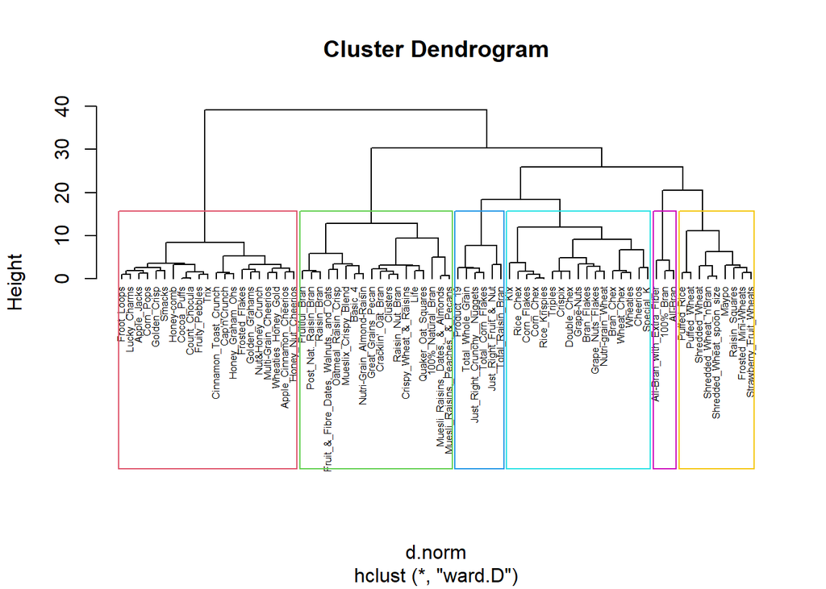

```r
# Computing distance based on all variables
d.norm <- dist(Cereals.df.norm, method="euclidean")

hc <- hclust(d.norm, method="ward.D")
plot(hc, hang=-1, cex=0.5)

# Displaying cluster rectangles
rect.hclust(hc, k=6, border=2:7)
```

It appears that 6 is a good number of clusters to use, as there is a relatively large gap in the height between cluster groupings between cluster groupings from the height of 13 to the height of 18. 4 clusters might be a good choice for a similar reason, but I will stick to 6 clusters.

## Selecting a Healthy Set of Cereals

Using a few functions from the `dplyr` package, we can easily compare the clusters.

```r
# Cutting the Tree into 6 clusters
Cereals.df.norm$hc_cut <- cutree(hc, 6)

# Printing out the mean of each variable, grouped by cluster
Cereals.df.norm %>% group_by(hc_cut) %>% summarise_all(mean) %>% round(2)
```

```
## # A tibble: 6 x 14
##   hc_cut calories protein   fat sodium fiber carbo sugars potass vitamins shelf
##    <dbl>    <dbl>   <dbl> <dbl>  <dbl> <dbl> <dbl>  <dbl>  <dbl>    <dbl> <dbl>
## 1      1    -2.2     1.38 -0.33   0.17  3.64 -2.07  -0.79   2.98    -0.18  0.94
## 2      2     0.77    0.61  1.05  -0.12  0.39 -0.3    0.46   0.73    -0.24  0.81
## 3      3     0.2    -0.92  0      0.12 -0.66 -0.54   0.96  -0.74    -0.18 -0.66
## 4      4    -0.18    0.23 -0.53   0.78 -0.17  0.96  -0.89  -0.31    -0.18 -0.4
## 5      5    -1.25   -0.06 -0.88  -1.94 -0.03  0.16  -1.1   -0.11    -0.8  -0.26
## 6      6     0.49    0.14 -0.17   0.56 -0.14  0.88  -0.18  -0.04     3.18  0.94
## # ... with 3 more variables: weight <dbl>, cups <dbl>, rating <dbl>
```

However, since these numbers have been normalized, this table can be hard to understand. We can fix this issue by applying the clusters we found above to the unnormalized data frame and applying the same procedure.

```r
# Cutting the Tree into 6 clusters
Cereals.df.unnorm <- Cereals.df[, -c(1, 2, 3)]
Cereals.df.unnorm$hc_cut <- cutree(hc, 6)
row.names(Cereals.df.unnorm) <- Cereals.df[,1]

# Printing out the mean of each variable, grouped by cluster
Cereals.df.unnorm %>% group_by(hc_cut) %>% summarise_all(mean) %>% round(2)
```

```
## # A tibble: 6 x 14
##   hc_cut calories protein   fat sodium fiber carbo sugars potass vitamins shelf
##    <dbl>    <dbl>   <dbl> <dbl>  <dbl> <dbl> <dbl>  <dbl>  <dbl>    <dbl> <dbl>
## 1      1     63.3    4     0.67 177.   11     6.67   3.67  310       25    3
## 2      2    122.     3.17  2.06 152.    3.11 13.6    9.11  150.      23.6  2.89
## 3      3    111.     1.52  1    172.    0.57 12.6   11.3    46.0     25    1.67
## 4      4    104.     2.76  0.47 227.    1.76 18.5    3.24   76.5     25    1.88
## 5      5     82.2    2.44  0.11   1.67  2.11 15.3    2.33   90.6     11.1  2
## 6      6    117.     2.67  0.83 208.    1.83 18.2    6.33   95.8    100    3
## # ... with 3 more variables: weight <dbl>, cups <dbl>, rating <dbl>
```

What “healthy” means might differ from school to school. But for the sake of example, a school looking for low-fat, low-sugar options might consider cereals from clusters 1, 4 and 5. Cluster 5 minimizes those variables, while being comparable in other areas except vitamins. If vitamins are considered important as well, then the school might go for cluster 4 instead.

```r
Cereals.df.unnorm %>% filter(hc_cut==4) %>% row.names
```

```
##  [1] "Bran_Chex"         "Bran_Flakes"       "Cheerios"
##  [4] "Corn_Chex"         "Corn_Flakes"       "Crispix"
##  [7] "Double_Chex"       "Grape_Nuts_Flakes" "Grape-Nuts"
## [10] "Kix"               "Nutri-grain_Wheat" "Rice_Chex"
## [13] "Rice_Krispies"     "Special_K"         "Triples"
## [16] "Wheat_Chex"        "Wheaties"
```